# Time Series Forecasting - Practice Exercise - Week 3 - Solution

# Predict on the Test Set using this model and evaluate the model on the test set using RMSE and MAPE

```python
predicted_autoSARIMA_ses_diff = results_SARIMA_ses_diff.forecast(steps=len(test))
predicted_autoSARIMA_ses_diff
```

```
1977-01-01    332.420132
1977-02-01    333.210511
1977-03-01    333.904347
1977-04-01    335.130921
1977-05-01    335.725438
1977-06-01    335.237644
1977-07-01    333.974148
1977-08-01    332.126618
1977-09-01    330.456479
1977-10-01    330.347820
1977-11-01    331.497223
1977-12-01    332.654664
1978-01-01    333.602773
1978-02-01    334.391741
1978-03-01    335.110334
1978-04-01    336.320632
1978-05-01    336.890534
1978-06-01    336.407603
1978-07-01    335.137290
1978-08-01    333.250249
1978-09-01    331.587511
1978-10-01    331.445259
1978-11-01    332.612506
1978-12-01    333.790150
1979-01-01    334.735263
1979-02-01    335.524675
1979-03-01    336.243202
1979-04-01    337.453510
1979-05-01    338.023411
1979-06-01    337.540480
1979-07-01    336.270167
1979-08-01    334.383126
1979-09-01    332.720388
1979-10-01    332.578136
1979-11-01    333.745383
1979-12-01    334.923027
1980-01-01    335.868140
1980-02-01    336.657552
1980-03-01    337.376079
1980-04-01    338.586387
1980-05-01    339.156288
1980-06-01    338.673357
1980-07-01    337.403044
1980-08-01    335.516003
1980-09-01    333.853265
1980-10-01    333.711013
1980-11-01    334.878260
1980-12-01    336.055904
Freq: MS, dtype: float64
```

```python
RMSE_autoSARIMA_ses_diff = mean_squared_error(test['CO2 ppm'],predicted_autoSARIMA_ses_diff)
MAPE_autoSARIMA_ses_diff = MAPE(test['CO2 ppm'],predicted_autoSARIMA_ses_diff)

print('RMSE for the autofit seasonal differenced SARIMA model:',RMSE_autoSARIMA_ses_diff,'\nMAPE for the autofit ARIMA model:',MAPE_autoSARIMA_ses_diff)
```

```
RMSE for the autofit seasonal differenced SARIMA model: 1.8855889983240128
MAPE for the autofit ARIMA model: 0.36
```

```python
temp_resultsDf = pd.DataFrame({'RMSE': [RMSE_autoSARIMA_ses_diff],'MAPE':[MAPE_autoSARIMA_ses_diff]}
                           ,index=['SARIMA(1, 1, 0)(0,1,2)12'])

resultsDf = pd.concat([resultsDf, temp_resultsDf])
resultsDf
```

|  | RMSE | MAPE |
| --- | --- | --- |
| ARIMA(2,1,1) | 4.753883 | 1.20 |
| SARIMA(1, 1, 0)(1,0,2)12 | 1.527622 | 0.41 |
| SARIMA(1, 1, 0)(0,1,2)12 | 1.885589 | 0.36 |

# Build a model on the whole data using the parameters got from best fit (with respect to the lowest AIC value) SARIMA model.

```python
import statsmodels.api as sm

mod = sm.tsa.statespace.SARIMAX(df['CO2 ppm'],
                                order=(1,1,0),
                                seasonal_order=(0, 1, 2, 12),
                                enforce_stationarity=False,
                                enforce_invertibility=False)
results_SARIMA_fullmodel_ses_diff = mod.fit()
print(results_SARIMA_fullmodel_ses_diff.summary())
```

```
                                        SARIMAX Results
===============================================================================================
Dep. Variable:                                 CO2 ppm   No. Observations:                  192
Model:             SARIMAX(1, 1, 0)x(0, 1, [1, 2], 12)   Log Likelihood                 -40.590
Date:                                 Thu, 25 Jun 2020   AIC                             89.181
Time:                                         18:47:51   BIC                            101.328
Sample:                                     01-01-1965   HQIC                            94.115
                                          - 12-01-1980
Covariance Type:                                   opg
==============================================================================
                 coef    std err          z      P>|z|      [0.025      0.975]
------------------------------------------------------------------------------
ar.L1         -0.2441      0.083     -2.937      0.003      -0.407      -0.081
ma.S.L12      -0.8617      0.106     -8.164      0.000      -1.069      -0.655
ma.S.L24      -0.0029      0.104     -0.028      0.978      -0.207       0.202
sigma2         0.0933      0.009     10.327      0.000       0.076       0.111
===================================================================================
Ljung-Box (Q):                       41.61   Jarque-Bera (JB):                15.20
Prob(Q):                              0.40   Prob(JB):                         0.00
Heteroskedasticity (H):               1.13   Skew:                             0.41
Prob(H) (two-sided):                  0.66   Kurtosis:                         4.30
===================================================================================

Warnings:
[1] Covariance matrix calculated using the outer product of gradients (complex-step).
```

# Forecast the values for the next 24 months using the SARIMA model built and plot them along with confidence intervals. Also, plot the existing time series data in this graph.

```python
pred_dynamic = results_SARIMA_fullmodel_ses_diff.get_prediction(start=pd.to_datetime('1981-01-01'), dynamic=True, full_results=True)
```

```python
pred_dynamic_ci = pred_dynamic.conf_int()
```

```python
pred95 = results_SARIMA_fullmodel_ses_diff.get_forecast(steps=24, alpha=0.05)
pred_ci_95 = pred95.conf_int()
```

```python
forecast_fullmodel_autosarima_ses_diff = pred95.predicted_mean
```

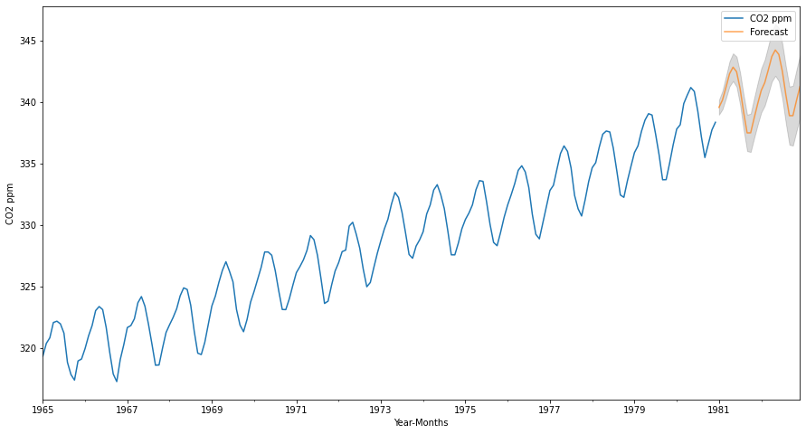

```python
# plot the forecast along with the confidence band

axis = df.plot(label='Observed', figsize=(15, 8))
forecast_fullmodel_autosarima_ses_diff.plot(ax=axis, label='Forecast', alpha=0.7)
axis.fill_between(forecast_fullmodel_autosarima_ses_diff.index, pred_ci_95['lower CO2 ppm'], pred_ci_95['upper CO2 ppm'], color='k', alpha=.15)
axis.set_xlabel('Year-Months')
axis.set_ylabel('CO2 ppm')
plt.legend(loc='best')
plt.show()
```

### Try building various models by tweaking the parameters by looking at the ACF and PACF plots.